# Chapter 8: Logistic analysis

GSMS Basic Medical Statistics

## Exercise 1

Use the Low Birth Weight dataset (lowbwt.sav) to answer the following questions. The variable LOW is coded as 1 if the birth weight < 2500 grams (0 otherwise).

1. Is there a significant difference in LOW risk for children of black mothers and other mothers? Give the CI for the OR. (Hint: Use the last category as the reference.)

**Answer**: The code below loads the dataset, setting the reference levels for the low birthweight (reference: `normal`) and for `RACE` (reference: `others`).

```r
bwt <- read_sav("data/lowbwt.sav") |>
  mutate(
    LOW.numeric = 1 - LOW,
    LOW  = factor(LOW, labels = c("low", "normal")),
    LOW  = fct_relevel(LOW, "normal"),
    RACE = factor(
      RACE,
      labels = c("white", "black", "others")
      ),
    RACE = fct_relevel(RACE, "others")
    )


bwt |>
  table1(~RACE | LOW, data = _, overall = FALSE, caption = "Low birthweight distribution")
```

Low birthweight distribution

|  | normal (N=59) | low (N=130) |
| --- | --- | --- |
| RACE |  |  |
| others | 25 (42.4%) | 42 (32.3%) |
| white | 23 (39.0%) | 73 (56.2%) |
| black | 11 (18.6%) | 15 (11.5%) |

The odds of a low birthweight among “blacks” is $\frac{15}{11} = 1.36$, whereas the odds among “others” is $\frac{42}{25} = 1.68$. The ratio between these two odds is $\frac{15/11}{42/25} = 0.812$, indicating that the “black” category has a lower rate of low birthweight than “others”. A Chi-Square test yields a $\chi^2=5, df=2$ which is associated with a nearly significant p-value of 0.08.

```r
ctest <- with(
  bwt,
  chisq.test(RACE, LOW)
  )

ctest
```

```
##
##  Pearson's Chi-squared test
##
## data:  RACE and LOW
## X-squared = 5, df = 2, p-value = 0.08
```

Another way of getting this answer is by means of a logistic regression, indicating that RACE is categorical and taking the third group (others) as reference group. Also ask for the 95% CI for exp(B) in Options.

```r
glm(LOW ~ RACE, bwt, family = binomial) |>
  modelsummary(
    exponentiate = TRUE,
    stars = TRUE,
    estimate = "{estimate} ({std.error})",
    statistic = "p={p.value}{stars} CI = [{conf.low}; {conf.high}]",
    gof_omit = "RMSE|F|Log",
    notes = "+ p<0.1, * p<0.05"
    )
```

|  | (1) |
| --- | --- |
| (Intercept) | 1.680 (0.424) |
|  | p=0.040* CI = [1.032; 2.792] |
| RACEwhite | 1.889 (0.657) |
|  | p=0.067+ CI = [0.957; 3.758] |
| RACEblack | 0.812 (0.382) |
|  | p=0.657 CI = [0.323; 2.072] |
| Num.Obs. | 189 |
| AIC | 235.7 |
| BIC | 245.4 |

+ p<0.1, * p<0.05

This table shows that our reference group (RACE = “other”) is associated with odds of low birthweight of $1.68$, which we saw from the direct calculation $\frac{42}{25} = 1.68$.

The odds-ratio of “black” to “others” is $0.812$ ($P=0.657$); the 95% CI is [0.323; 2.07]. The risk of LOW for children of “black” mothers is not significantly different (P=0.657) from that of “others” mothers.

2. Categorize AGE in 5 classes as in Figure 8.2.8, calculate the mean age (X) and the proportion of LOW children per class (P) and plot logit(P) against X.

**Answer**: The code below uses the `chop_equally` function from the [`santoku` package](https://hughjonesd.github.io/santoku/) to divide the data into five age classes:

- Ages $\le18, n = 35$
- Ages between $[19; 20], n = 34$
- Ages between $[21; 23], n = 38$
- Ages between $[24; 27], n = 37$
- Ages $\ge28, n = 43$

```r
# Create a dataset for the five age strata.
# For each strata calculate the mean age (age_bar)
# and the mean birth-weight (bwt_bar).
bwt.AGE5 <- bwt |>
  mutate(AGE5 = chop_equally(AGE, 5)) |>
  summarise(
    n = n(),
    age_bar = mean(AGE),
    bwt_bar  = mean(as.numeric(LOW) - 1),
    .by = AGE5
    ) |>
  arrange(AGE5)
```

Now that we have the age groups, we can create the diagram below:

- Birthweight against age (black dots),
- The proportions of low birthweights in five age classes (green diamonds)
- the fitted logistic curve (blue)
- the fitted linear regression (red dashed line)

Notice hat although the assumptions of the linear model are dramatically violated, we can clearly see that the linear model does a very good job in approximating the logistic model.

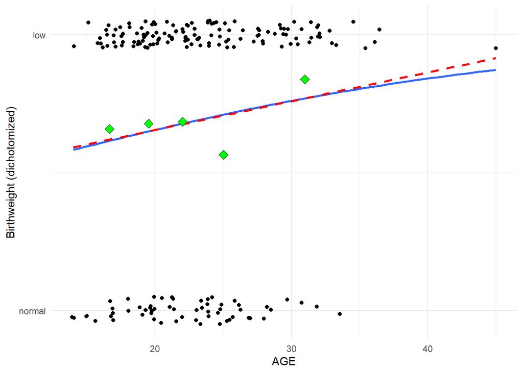

```r
# Now show the observations, the binomial model
# of probabilities as well as the means of
# the stratified dataset.
bwt |>
  mutate(LOW = as.numeric(LOW) - 1) |>
  ggplot(aes(AGE, LOW)) +
  geom_jitter(height = .05, width = .5) +
  geom_smooth(
    method = "glm",
    method.args = list(family = "binomial"),
    se = FALSE
    ) +
  geom_smooth(
    method = "lm",
    se = FALSE,
    color = "red",
    linetype = "dashed"
    ) +
  geom_point(
    data = bwt.AGE5,
    aes(age_bar, bwt_bar),
    shape = 23,
    size = 3,
    fill = "green"
    ) +
  scale_y_continuous(
    name = "Birthweight (dichotomized)",
    breaks = c(0, 1),
    labels = c("normal", "low")
    )
```

3. Compare the fit of the model with AGE, SMOKE and RACE to that of the model with AGE and SMOKE. (Use the LR test.)

**Answer**: In Model summary of the two models you will find the log likelihood of the two models. Subtracting these values gives the value of the likelihood ratio statistic, we find that the $2\cdot LR = 2\cdot -109.431 - (-113.638) = 8.42$. Under the null hypothesis, this statistics is distributed as a $\chi^2, df=2$. The probability of observing this statistic is therefore `pchisq(8.42, df = 2, lower.tail = FALSE) =` 0.0148.

```r
m0 <- bwt |>
  glm(LOW.numeric ~ AGE, data = _, family = "binomial")

m1 <- bwt |>
  glm(LOW.numeric ~ AGE + SMOKE, data = _, family = "binomial")

m2 <- bwt |>
  glm(LOW.numeric ~ AGE + SMOKE + RACE, data = _, family = "binomial")

m3 <- bwt |>
  glm(
    LOW.numeric ~ AGE + (SMOKE + RACE)^2,
    data = _,
    family = "binomial"
    )

modelsummary(
  title = "Modelling low birthweight",
  list(m0, m1, m2, m3),
  estimate = "{estimate} ({std.error})",
  statistic = "p={p.value}{stars}",
  stars = TRUE,
  gof_omit = "RMSE|F"
  )
```

Modelling low birthweight

|  | (1) | (2) | (3) | (4) |
| --- | --- | --- | --- | --- |
| (Intercept) | −0.385 (0.732) | −0.061 (0.757) | −0.049 (0.791) | −0.122 (0.820) |
|  | p=0.599 | p=0.936 | p=0.950 | p=0.882 |
| AGE | 0.051 (0.032) | 0.050 (0.032) | 0.035 (0.033) | 0.031 (0.035) |
|  | p=0.105 | p=0.119 | p=0.296 | p=0.378 |
| SMOKE |  | −0.692 (0.322) | −1.101 (0.372) | −0.228 (0.651) |
|  |  | p=0.032* | p=0.003** | p=0.726 |
| RACEwhite |  |  | 1.057 (0.406) | 1.642 (0.604) |
|  |  |  | p=0.009** | p=0.007** |
| RACEblack |  |  | 0.045 (0.491) | 0.303 (0.615) |
|  |  |  | p=0.926 | p=0.622 |
| SMOKE × RACEwhite |  |  |  | −1.435 (0.890) |
|  |  |  |  | p=0.107 |
| SMOKE × RACEblack |  |  |  | −1.098 (1.076) |
|  |  |  |  | p=0.307 |
| Num.Obs. | 189 | 189 | 189 | 189 |
| AIC | 235.9 | 233.3 | 228.9 | 230.0 |
| BIC | 242.4 | 243.0 | 245.1 | 252.7 |
| Log.Lik. | −115.956 | −113.638 | −109.431 | −108.016 |

We can also run a likelihood ratio test directly, which results in the same p-value we calculated manually, $p = 0.015$, suggesting that we can reject the null hypothesis that the two models are equivalent.

```r
lmtest::lrtest(m1, m2)
```

```
## Likelihood ratio test
##
## Model 1: LOW.numeric ~ AGE + SMOKE
## Model 2: LOW.numeric ~ AGE + SMOKE + RACE
##   #Df LogLik Df Chisq Pr(>Chisq)
## 1   3   -114
## 2   5   -109  2  8.41      0.015 *
## ---
## Signif. codes:  0 '***' 0.001 '**' 0.01 '*' 0.05 '.' 0.1 ' ' 1
```

**NOTE:** Notice that the first model allows us to interpret the effect of age on the rate of low-birthrate by recourse to odds ratio: every additional year in a mother’s age increases her baby’s odds by a factor of $\exp(0.051) = 1.052$ or about 5%. But it is hard to fully grasp what an increase of 5% in terms of odds actually means in terms of probabilities.

To address this issue, we could either inspect the slope of the linear regression (which turns out to be 0.0104, suggesting that every year is associated with an increase in probability of about 0.0104), or use the `marginaleffects` package to find that the marginal effect of one additional year in a mother’s age is associated with an additional 0.0107 in the probability of her baby being born with a low birth weight, as can be seen in the code below:

```r
library(marginaleffects)
m0 |> avg_comparisons(variable = "AGE") |>
  as_tibble()
```

```
## # A tibble: 1 × 9
##   term  contrast estimate std.error statistic p.value s.value conf.low conf.high
##   <chr> <chr>       <dbl>     <dbl>     <dbl>   <dbl>   <dbl>    <dbl>     <dbl>
## 1 AGE   +1         0.0107   0.00640      1.68  0.0937    3.42 -0.00182    0.0233
```

You thus have the option of saying either that the odds of having a low-birth weight increase by a factor of about 5% **or** that the probability increases by an additional 0.01 (on average) for every additional year in mother’s age.

4. Is effect of smoking different for different RACE-groups?

**Answer**: On fitting a model with RACE, SMOKE and RACE*SMOKE (see the last model in the previous section) we find that the interaction is not significant. We do not have evidence for a different effect of smoking in different RACE-groups. We can also test the models with and without interactions using the likelihood ratio test, again finding no significant difference between the models (p = 0.24).

```r
lmtest::lrtest(m2, m3)
```

```
## Likelihood ratio test
##
## Model 1: LOW.numeric ~ AGE + SMOKE + RACE
## Model 2: LOW.numeric ~ AGE + (SMOKE + RACE)^2
##   #Df LogLik Df Chisq Pr(>Chisq)
## 1   5   -109
## 2   7   -108  2  2.83       0.24
```

## Exercise 2

Multiple logistic regression were used to construct a prognostic index to predict coronary artery disease from data on 348 patients with valvular heart disease who had undergone routine coronary arteriography before valve replacement (Ramsdale et al. 1982). The estimated equation was:
$$\text{logit}(p) = \log(\text{Odds}) = \log\frac{p}{1-p} = b_0 +
1.167\cdot x_1 + 0.0106\cdot x_2 + \ldots$$

where $x_1$ stands for the family history of Ischemia (0=no, 1=yes) and $x_2$ is the estimated total number of cigarettes ever smoked in terms of thousand cigarettes, calculated as the average number smoked annually times the number of years smoking.

1. What is the estimated odds ratio for having coronary artery disease associated with a positive family history?

**Answer**: `exp(1.167) =` 3.2123.

2. What total number of cigarettes ever smoked carries the same risk as a positive family history? Convert the result into years of smoking 20 cigarettes per day.

**Answer**: The log(OR) of positive history, $1.167$, is to be set equal to $0.0106\cdot x_2$, where $0.0106$ is the log odds ratio of smoking 1000 cigarettes.

Thus $x_2=1.167/0.0106=110.094$ thousands of cigarettes. Dividing this result by $365\cdot20=7300$, or the total number cigarettes smoked in 1 year if smoking 20 cigarettes per day, we find $110094/7300=15.1$ or just above 15 years. Thus the odds ratio of positive history is equivalent to that of daily smoking of 20 cigarettes for about 15 years.

3. What is the odds ratio for coronary artery disease for someone with a positive family history who had smoked 20 cigarettes a day for 30 years compared to a non smoker with no family history?

**Answer**: The total number of cigarettes smoked is $20 \cdot365\cdot30 = 219000$, so the odds ratio is $\exp(1.167 + 219\cdot 0.0106) = 32.7$

## Exercise 3

Data from 37 patients receiving a non-depleted allogenic bone marrow transplant were examined to see which variables were associated with the occurrence of acute [graft-versus-host disease](https://en.wikipedia.org/wiki/Graft-versus-host_disease) (GvHD: 0=no, 1=yes) (Bagot et al., 1988).

Possible predictors are

- TYPE (type of leukemia: 1=AML, [acute myeloid leukemia](https://en.wikipedia.org/wiki/Acute_myeloid_leukemia); 2=ALL, [acute lymphocytic leukaemia](https://en.wikipedia.org/wiki/Acute_lymphoblastic_leukemia); 3=CML, [chronic myeloid leukemia](https://en.wikipedia.org/wiki/Chronic_myelogenous_leukemia)),
- PREG (donor pregnancy: 0= no, 1=yes) and
- LOGIND (the logarithm of an index of mixed epidermal cell-lymphocyte reactions).

Data are in a file EX8_3.SAV.

1. Examine separately the relation of each predictor with GvHD. What are your conclusions?

**Answer**: To examine the relation between GvHD and TYPE and PREG, we can try to use the chi-squared tests, but then we see that the expected values (under the null hypothesis) has one cell with an expected value that is lower than 5, violating the assumptions of the Chi-square test.

```r
options(digits = 3)
ex8_3 <- read_sav("data/Ex8_3.sav") |>
  mutate(
    gvhd.numeric = gvhd,
    gvhd = factor(gvhd, labels = c("no", "yes")),
    type = factor(type, labels = c("AML", "ALL", "CML")),
    type = fct_relevel(type, "CML"),
    preg = factor(preg, labels = c("no", "yes"))
    )

chi <- with(
  ex8_3,
  chisq.test(gvhd, type)
  )

chi$expected
```

```
##      type
## gvhd   CML  AML  ALL
##   no  5.41 5.95 8.65
##   yes 4.59 5.05 7.35
```

```r
chi <- with(
  ex8_3,
  chisq.test(gvhd, preg)
  )
chi$expected
```

```
##      preg
## gvhd    no  yes
##   no  14.6 5.41
##   yes 12.4 4.59
```

This means that we cannot use the Chi-square test and need to use Fisher’s exact test. Doing that in the code below, we can see that the relation between GvHD and TYPE is associated with p = 0.029 and its relationship with PREG is associated with p = 0.023.

```r
options(digits = 8)
with(
  ex8_3,
  fisher.test(gvhd, type)
  )
```

```
##
##  Fisher's Exact Test for Count Data
##
## data:  gvhd and type
## p-value = 0.028787
## alternative hypothesis: two.sided
```

```r
with(
  ex8_3,
  fisher.test(gvhd, preg)
  )
```

```
##
##  Fisher's Exact Test for Count Data
##
## data:  gvhd and preg
## p-value = 0.023439
## alternative hypothesis: true odds ratio is not equal to 1
## 95 percent confidence interval:
##   1.1704288 87.4034598
## sample estimates:
## odds ratio
##  7.5259188
```

Both the type and the pregnancy status have a siginificant effect on the result at the 5% level. We can compare LOGIND in the GvHD groups by the two sample t-test

```r
with(
  ex8_3,
  t.test(logind ~ gvhd)
  )
```

```
##
##  Welch Two Sample t-test
##
## data:  logind by gvhd
## t = -4.00909, df = 34.703, p-value = 0.00030739
## alternative hypothesis: true difference in means between group no and group yes is not equal to 0
## 95 percent confidence interval:
##  -1.51278005 -0.49551523
## sample estimates:
##  mean in group no mean in group yes
##        0.11084197        1.11498961
```

A Welch two sample t-test shows a significant result (P<0.001). Thus, in univariate analyses, all three explanatory variables are significantly associated to GvHD. We can also run three simple logistic regressions, yielding similar conclusions:

```r
m1 <- glm(gvhd.numeric ~ type, ex8_3, family = "binomial")
m2 <- glm(gvhd.numeric ~ preg, ex8_3, family = "binomial")
m3 <- glm(gvhd.numeric ~ logind, ex8_3, family = "binomial")

Anova(m1, type = 3)
```

```
## Analysis of Deviance Table (Type III tests)
##
## Response: gvhd.numeric
##      LR Chisq Df Pr(>Chisq)
## type   7.8884  2   0.019367 *
## ---
## Signif. codes:  0 '***' 0.001 '**' 0.01 '*' 0.05 '.' 0.1 ' ' 1
```

```r
Anova(m2, type = 3)
```

```
## Analysis of Deviance Table (Type III tests)
##
## Response: gvhd.numeric
##      LR Chisq Df Pr(>Chisq)
## preg  6.66957  1  0.0098073 **
## ---
## Signif. codes:  0 '***' 0.001 '**' 0.01 '*' 0.05 '.' 0.1 ' ' 1
```

```r
Anova(m3, type = 3)
```

```
## Analysis of Deviance Table (Type III tests)
##
## Response: gvhd.numeric
##        LR Chisq Df Pr(>Chisq)
## logind  13.3099  1 0.00026401 ***
## ---
## Signif. codes:  0 '***' 0.001 '**' 0.01 '*' 0.05 '.' 0.1 ' ' 1
```

2. Carry out a multiple logistic regression analysis with predictors which were significant in (a). Which variables are now significantly related to GvHD? Interpret the results in terms of odds ratios.

```r
m4 <- ex8_3 |>
  select(-gvhd, -patient) |>
  glm(gvhd.numeric ~ ., data = _ , family = "binomial")

modelsummary(
  title = "Modelling GvHD (outcome variable)",
  list(m1, m2, m3, m4),
  exponentiate = TRUE,
  estimate = "{estimate} ({std.error})",
  statistic = "p={p.value}{stars}",
  stars = TRUE,
  gof_omit = "RMSE|F"
  )
```

Modelling GvHD (outcome variable)

|  | (1) | (2) | (3) | (4) |
| --- | --- | --- | --- | --- |
| (Intercept) | 4.000 (3.162) | 0.500 (0.204) | 0.274 (0.163) | 0.762 (0.811) |
|  | p=0.080+ | p=0.090+ | p=0.030* | p=0.799 |
| typeAML | 0.208 (0.207) |  |  | 0.113 (0.141) |
|  | p=0.115 |  |  | p=0.079+ |
| typeALL | 0.083 (0.082) |  |  | 0.098 (0.123) |
|  | p=0.011* |  |  | p=0.065+ |
| pregyes |  | 8.000 (7.118) |  | 12.160 (13.408) |
|  |  | p=0.019* |  | p=0.023* |
| logind |  |  | 5.686 (3.459) | 4.296 (3.242) |
|  |  |  | p=0.004** | p=0.053+ |
| Num.Obs. | 37 | 37 | 37 | 37 |
| AIC | 49.2 | 48.4 | 41.7 | 38.8 |
| BIC | 54.0 | 51.6 | 45.0 | 46.9 |
| Log.Lik. | −21.580 | −22.190 | −18.870 | −14.416 |

**Answer**: LOGIND: OR=4.30, P=0.053+; PREG: OR=12.2, P=0.023*; TYPE: P=0.126 (OR’s of AML:CML and ALL:CML are smaller than 1). Pregnancy has significantly (at 5% level) higher risk of GvHD. No significant effect of LONGIND and TYPE was found.

3. Give the 90% confidence intervals for the odds ratios.

**Answer**: You can set the `conf_level` argument in the `modelsummary` function to override the default 95% for the CI and set it to 90%. Running the analysis again, we find the following results:

```r
modelsummary(m4,
             conf_level = 0.90,
               estimate = "{estimate} ({std.error}){stars}",
             statistic = "CI = [{conf.low}, {conf.high}], p = {p.value}",
             exponentiate = TRUE,
  gof_omit = "RMSE|F")
```

|  | (1) |
| --- | --- |
| (Intercept) | 0.762 (0.811) |
|  | CI = [0.127, 4.811], p = 0.799 |
| typeAML | 0.113 (0.141)+ |
|  | CI = [0.012, 0.781], p = 0.079 |
| typeALL | 0.098 (0.123)+ |
|  | CI = [0.010, 0.692], p = 0.065 |
| pregyes | 12.160 (13.408)* |
|  | CI = [2.256, 91.592], p = 0.023 |
| logind | 4.296 (3.242)+ |
|  | CI = [1.424, 18.287], p = 0.053 |
| Num.Obs. | 37 |
| AIC | 38.8 |
| BIC | 46.9 |
| Log.Lik. | −14.416 |

- AML:CML: 0.012 to 0.781;
- ALL:CML: 0.01 to 0.692;
- PREG: 2.26 to 91.6;
- LOGIND: 1.42 to 18.3;
4. After inspection of the results, investigators note that there are hardly any differences between ALL and AML and decide to fit a model with, instead of TYPE, only an indicator variable for CML. Carry out this analysis. What are your conclusions? Comment on the appropriateness of the method of model building.

**Answer**: By collapsing the levels `AML` and `ALL` into one level (CML = `no`), we see OR of CML (yes vs. no) becomes significant at 5% level (P=0.042).

```r
ex8_3 |>
  mutate(
    CML = fct_collapse(
      type,
      no = c("AML", "ALL"),
      yes = "CML"
      ),
    CML = fct_relevel(CML, "no")
    ) |>
  glm(gvhd.numeric ~ CML + preg + logind, data = _ , family = "binomial") |>
  modelsummary(exponentiate = TRUE,
  estimate = "{estimate} ({std.error}) p={p.value}{stars}",
  statistic = NULL,
  stars = TRUE,
  gof_omit = "RMSE|F"
  )
```

|  | (1) |
| --- | --- |
| (Intercept) | 0.078 (0.074) p=0.007** |
| CMLyes | 9.493 (10.500) p=0.042* |
| pregyes | 12.128 (13.355) p=0.023* |
| logind | 4.427 (3.186) p=0.039* |
| Num.Obs. | 37 |
| AIC | 36.8 |
| BIC | 43.3 |
| Log.Lik. | −14.424 |

Two comments on this:

- Do we have a theoretical base for combining the groups ALL and AML to compare the combined group to CML?
- Reducing the number of categories of a categorical variable (deleting dummy variables from the model) on basis of tests raises the issue of multiple comparisons: the actual significance level becomes higher than the nominal level of 5%. Without a control of the type I error the analysis becomes explorative and should be reported as such.